# Decomposition Analysis Demo

Yu Chen, José Manuel Aburto

2026-03-12

# Preamble

The aim of this exercise is to apply the linear integral model proposed by Horiuchi et al (2008) and stepwise replacement method proposed by Andreev et al. (2002). The example is applied to life expectancy for Venezuelan males.

The aim is to quantify the effect of age-specific mortality changes on life expectancy between 1996 and 2013, and quantify the contribution of cause of death (CoD).

The CoD object contains life table and cause of death data for the years 1996 and 2013. Names 1:10 are ten independent, cause-of-death groups.

You can choose any two years that you want to do the decomposition.

# Installation

```r
# TODO: install the packages if you haven't already
# install.packages("DemoDecomp")
# install.packages("ggpubr")
require(ggplot2)
require(tidyr)
require(DemoDecomp)
```

# Load data and source functions

```r
load('Decomp_Data_L4.RData')
```

We already have a function for life expectancy and for the decomp algorithm

```r
#load some functions and some info for graphs
source('Functions_5.R')
```

# Decomposition Analyses for life expectancy

## Set up

Following the method, we require two vectors of rates: one for 2013 and one for 1996.

```r
ref.yr <- 1996
tar.yr <- 2013

# we need age-cause specific mortality rates in each CoD
COD1 <- as.matrix(
  cause.age.specific.mx[cause.age.specific.mx$year==ref.yr,
                        1:10]
  )


COD2 <- as.matrix(
  cause.age.specific.mx[cause.age.specific.mx$year==tar.yr,
                        1:10]
  )
```

### Question: How to set the function for the decomposition by CoD?

Recall what we learnt yesterday

```r
e0.frommx
```

```
## function (nmx = mx, sex = 1, age = c(0, 1, seq(5, 85, 5)), nax = NULL)
## {
##     n <- c(diff(age), 999)
##     if (is.null(nax)) {
##         nax <- 0.5 * n
##         if (n[2] == 4) {
##             if (sex == 1) {
##                 if (nmx[1] >= 0.107) {
##                   nax[1] <- 0.33
##                   nax[2] <- 1.352
##                 }
##                 else {
##                   nax[1] <- 0.045 + 2.684 * nmx[1]
##                   nax[2] <- 1.651 - 2.816 * nmx[1]
##                 }
##             }
##             if (sex == 2) {
##                 if (nmx[1] >= 0.107) {
##                   nax[1] <- 0.35
##                   nax[2] <- 1.361
##                 }
##                 else {
##                   nax[1] <- 0.053 + 2.8 * nmx[1]
##                   nax[2] <- 1.522 - 1.518 * nmx[1]
##                 }
##             }
##         }
##     }
##     nqx <- (n * nmx)/(1 + (n - nax) * nmx)
##     nqx <- c(nqx[-(length(nqx))], 1)
##     nqx[nqx > 1] <- 1
##     npx <- 1 - nqx
##     lx <- cumprod(c(1, npx))
##     ndx <- -diff(lx)
##     lxpn <- lx[-1]
##     nLxpn <- n * lxpn + ndx * nax
##     nLx <- c(nLxpn[-length(nLxpn)], lxpn[length(lxpn) - 1]/nmx[length(nmx)])
##     Tx <- rev(cumsum(rev(nLx)))
##     lx <- lx[1:length(age)]
##     ex <- Tx/lx
##     e0 <- ex[1]
##     return(e0)
## }
```

TRICK: What we need is then a function that gives a long vector with the same order as the input of the decomposition, which is a vector of age-cause specific mortality.

```r
e0frommxc <- function(mxcvec,sex=1){
  dim(mxcvec) <- c(19,length(mxcvec)/19)
  mx          <- rowSums(mxcvec)
  e0.frommx(mx,sex)
}
```

*QUESTION:*

- Why do we need to set the function like this?

- What does the ‘dim’ function do in this case?

- What does the ‘rowSums’ function do in this case?

- What does the number 19 mean in this case?

## Horiuchi decomposition

Now use the Horiuchi decomposition. First set your N input, which is the number of steps in the decomposition. The higher the N, the more accurate the decomposition, but it will take more time to run.

```r
# TODO: note to change
N.input <- 1e3 # you can try 10, 100, 1e4...

# horiuchi decomposition
horiuchi.results.raw <- horiuchi(
  func = e0frommxc,
  pars1 = c(COD1),
  pars2 = c(COD2),
  N = N.input)

dim(horiuchi.results.raw) <- dim(COD1)
horiuchi.results.raw
```

```
##                [,1]          [,2]          [,3]          [,4]          [,5]
##  [1,]  4.217918e-03  0.0008808139  7.420893e-04  0.0098113760  0.0019523740
##  [2,]  4.289051e-03  0.0076390278  5.336350e-04 -0.0008564005  0.0127357267
##  [3,]  4.003514e-03  0.0022921593 -1.112929e-04 -0.0039980231  0.0172048403
##  [4,]  2.960660e-03  0.0038052664  3.035201e-05  0.0002222279  0.0086199839
##  [5,]  4.590370e-03 -0.0001051925  1.216235e-03 -0.3015918245 -0.0398756721
##  [6,] -8.664124e-04  0.0016863483 -4.726468e-04 -0.4632924148 -0.0690744470
##  [7,]  2.747243e-03  0.0010329431 -2.025241e-03 -0.2829054398 -0.0317993034
##  [8,] -5.270914e-05 -0.0001320688 -8.731374e-03 -0.1592305823 -0.0071370873
##  [9,]  1.055335e-03  0.0099783420 -4.592429e-03 -0.0765550520  0.0003143796
## [10,]  3.817584e-02  0.0023606491 -5.594205e-03 -0.0398057874  0.0146184546
## [11,]  1.180051e-02  0.0064653730  4.069769e-03 -0.0225122460  0.0471929105
## [12,]  3.009605e-02 -0.0025946048 -1.446968e-02 -0.0287881318  0.0120136887
## [13,]  8.301949e-02 -0.0027903949 -2.391967e-02 -0.0067918616  0.0175178172
## [14,]  1.171585e-01  0.0286319294 -3.134130e-02 -0.0090071668  0.0187071827
```

[output cut: 25 more lines]

Check if our decomposed contributions sum up to the original difference…

```r
original <- e0frommxc(COD2) - e0frommxc(COD1)
with.decomp <- sum(horiuchi.results.raw)
cat('\nThe difference between the sum of the decomposed contributions and the original difference is:', with.decomp - original, ' with the N used in the decomposition is', N.input)
```

```
##
## The difference between the sum of the decomposed contributions and the original difference is: -2.389181e-08  with the N used in the decomposition is 1000
```

Restructure the data to have a nice dataset for graphing

```r
horiuchi.results            <- data.frame(horiuchi.results.raw)
colnames(horiuchi.results)  <- cause_names
horiuchi.results$Age        <- age_names
horiuchi.results            <- gather(data = horiuchi.results,
                                      key = Cause,
                                      value = Contribution,
                                      -Age)
```

Figure: the results of the Horiuchi decomposition method

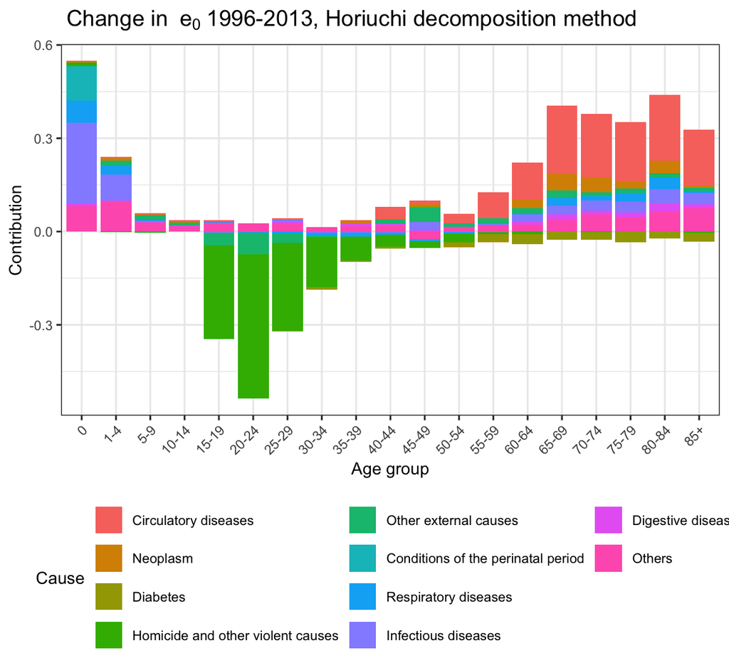

```r
p.horiuchi <-
  ggplot(data = horiuchi.results,
         aes(x = factor(Age,
                        levels = unique(horiuchi.results$Age)),
             y = Contribution,
             fill = factor(Cause,
                           levels = unique(horiuchi.results$Cause)))) +
  ggtitle(bquote(~'Change in '~ e[0] ~'1996-2013, Horiuchi decomposition method' ))+
  geom_bar(stat = "identity", position = "stack") +
  guides(fill = guide_legend(order = 1, ncol = 3)) +
  labs(x = "Age group", y = "Contribution", fill = "Cause") +
  theme_bw() +
  theme(
    axis.title       = element_text(size = 10),
    axis.text        = element_text(size = 8),
    axis.text.x      = element_text(angle = 45, vjust = 1, hjust=1),
    axis.line        = element_blank(),
    legend.title     = element_text(size = 10),
    legend.text      = element_text(size = 8),
    strip.text       = element_text(size = 10),
    panel.background = element_blank(),
    strip.background = element_blank(),
    legend.position  = "bottom"
  )
p.horiuchi
```

## Stepwise replacement decomposition

You can find the argument ‘direction’ in the ‘stepwise_replacement’ function. Now, choose the direction of decomposition you want to run. The default is ‘up’.

```r
help(stepwise_replacement)
# TODO: note to change
dir.pick <- "both" # or "down", "up"

stepwise.results.raw <- stepwise_replacement(
  e0frommxc,
  pars1 = c(COD1),
  pars2 = c(COD2),
  direction = dir.pick)

dim(stepwise.results.raw) <- dim(COD1)
stepwise.results.raw
```

```
##                [,1]          [,2]          [,3]          [,4]          [,5]
##  [1,]  4.222364e-03  0.0008805372  7.419635e-04  0.0098082417  0.0019518658
##  [2,]  4.293249e-03  0.0076359870  5.335063e-04 -0.0008560606  0.0127310344
##  [3,]  4.007739e-03  0.0022912010 -1.112652e-04 -0.0039963506  0.0171979868
##  [4,]  2.964041e-03  0.0038035393  3.034378e-05  0.0002221268  0.0086162282
##  [5,]  4.596090e-03 -0.0001051404  1.215875e-03 -0.3014338394 -0.0398569013
##  [6,] -8.676011e-04  0.0016854339 -4.724941e-04 -0.4630052302 -0.0690397898
##  [7,]  2.751407e-03  0.0010323193 -2.024508e-03 -0.2827117584 -0.0317818499
##  [8,] -5.279836e-05 -0.0001319792 -8.727790e-03 -0.1591125392 -0.0071326175
##  [9,]  1.057354e-03  0.0099706615 -4.590261e-03 -0.0764919172  0.0003141485
## [10,]  3.825897e-02  0.0023585557 -5.591121e-03 -0.0397679105  0.0146055294
## [11,]  1.183024e-02  0.0064586224  4.067110e-03 -0.0224867300  0.0471411620
## [12,]  3.018598e-02 -0.0025913279 -1.445809e-02 -0.0287480760  0.0119970720
## [13,]  8.331437e-02 -0.0027859707 -2.389480e-02 -0.0067798256  0.0174866079
## [14,]  1.176484e-01  0.0285730226 -3.129625e-02 -0.0089859030  0.0186626444
```

[output cut: 25 more lines]

```r
with.decomp <- sum(stepwise.results.raw)
cat('\nThe difference between the sum of the stepwise replacement decomposed contributions and the original difference is:', with.decomp - original, ' with the direction used in the decomposition is', dir.pick)
```

```
##
## The difference between the sum of the stepwise replacement decomposed contributions and the original difference is: 0  with the direction used in the decomposition is both
```

Rescrtructure the data to have a nice dataset for graphing

```r
stepwise.results            <- data.frame(stepwise.results.raw)
colnames(stepwise.results)  <- cause_names
stepwise.results$Age        <- age_names
stepwise.results            <- gather(data = stepwise.results,
                                      key = Cause,
                                      value = Contribution,
                                      -Age)
```

Figure: the results of the Stepwise replacement decomposition

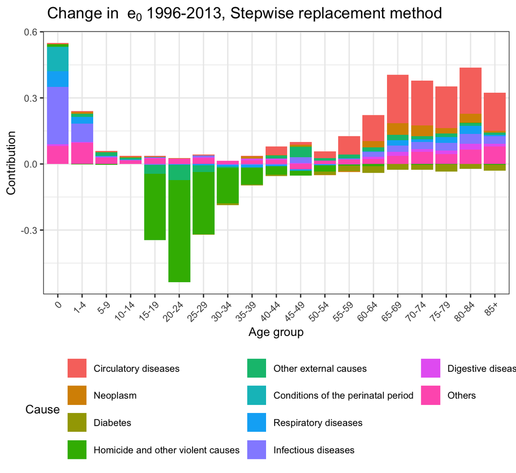

```r
p.stepwise <-
  ggplot(data = stepwise.results,
         aes(x = factor(Age,
                        levels = unique(stepwise.results$Age)),
             y = Contribution,
             fill = factor(Cause,
                           levels = unique(stepwise.results$Cause)))) +
  ggtitle(bquote(~'Change in '~ e[0] ~'1996-2013, Stepwise replacement method' ))+
  geom_bar(stat = "identity", position = "stack") +
  guides(fill = guide_legend(order = 1, ncol = 3)) +
  labs(x = "Age group", y = "Contribution", fill = "Cause") +
  theme_bw() +
  theme(
    axis.title       = element_text(size = 10),
    axis.text        = element_text(size = 8),
    axis.text.x      = element_text(angle = 45, vjust = 1, hjust=1),
    axis.line        = element_blank(),
    legend.title     = element_text(size = 10),
    legend.text      = element_text(size = 8),
    strip.text       = element_text(size = 10),
    panel.background = element_blank(),
    strip.background = element_blank(),
    legend.position  = "bottom"
  )
p.stepwise
```

## Comparison of the two methods

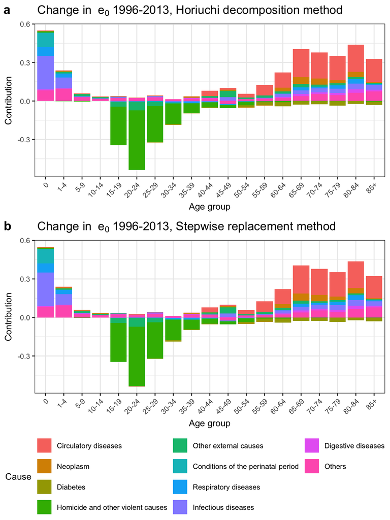

```r
p.both <-  ggpubr::ggarrange(p.horiuchi,
                             p.stepwise,
                             ncol = 1,
                             labels = c('a', 'b'),
                             common.legend = TRUE,
                             legend = 'bottom',
                             align = 'hv',
                             widths = c(1,1),
                             heights = c(1,1))
p.both
```

# Decomposition Analyses for lifespan variation

We can do the same for the standard deviation of the age at death distribution, which is a measure of lifespan variation. The function for the standard deviation of the age at death distribution is already defined in the Functions_5.R file. You can use the same code as before, but replace the function and the original difference with the standard deviation of the age at death distribution.

```r
# change the previous function to sdfrommxc
horiuchi.results.sd <- horiuchi(
  func = sdfrommxc,
  pars1 = c(COD1),
  pars2 = c(COD2),
  N = N.input)
dim(horiuchi.results.sd) <- dim(COD1)
horiuchi.results.sd
```

```
##                [,1]          [,2]          [,3]          [,4]          [,5]
##  [1,] -6.393545e-03 -1.335143e-03 -1.124863e-03 -1.487214e-02 -2.959420e-03
##  [2,] -6.233726e-03 -1.110260e-02 -7.755875e-04  1.244696e-03 -1.851016e-02
##  [3,] -5.316449e-03 -3.043863e-03  1.477910e-04  5.309158e-03 -2.284709e-02
##  [4,] -3.549595e-03 -4.562212e-03 -3.638964e-05 -2.664336e-04 -1.033467e-02
##  [5,] -4.904397e-03  1.123887e-04 -1.299437e-03  3.222237e-01  4.260356e-02
##  [6,]  8.121917e-04 -1.580815e-03  4.430682e-04  4.342993e-01  6.475172e-02
##  [7,] -2.215982e-03 -8.331929e-04  1.633600e-03  2.281973e-01  2.564996e-02
##  [8,]  3.560643e-05  8.921600e-05  5.898275e-03  1.075645e-01  4.821292e-03
##  [9,] -5.736124e-04 -5.423584e-03  2.496149e-03  4.161040e-02 -1.708765e-04
## [10,] -1.565710e-02 -9.681758e-04  2.294358e-03  1.632560e-02 -5.995484e-03
## [11,] -3.241384e-03 -1.775920e-03 -1.117891e-03  6.183705e-03 -1.296303e-02
## [12,] -4.108631e-03  3.542084e-04  1.975361e-03  3.930077e-03 -1.640076e-03
## [13,]  3.990742e-04 -1.341341e-05 -1.149817e-04 -3.264844e-05  8.420805e-05
## [14,]  1.750761e-02  4.278619e-03 -4.683494e-03 -1.345988e-03  2.795512e-03
```

[output cut: 25 more lines]

```r
#
stepwise.results.sd <-
  stepwise_replacement(
    sdfrommxc,
    pars1 = c(COD1),
    pars2 = c(COD2),
    direction = dir.pick)
dim(stepwise.results.sd) <- dim(COD1)
stepwise.results.sd
```

```
##                [,1]          [,2]          [,3]          [,4]          [,5]
##  [1,] -0.0063939343 -1.335953e-03 -1.125938e-03 -1.488177e-02 -2.988852e-03
##  [2,] -0.0062339587 -1.110843e-02 -7.762784e-04  1.245415e-03 -1.868749e-02
##  [3,] -0.0053173873 -3.045440e-03  1.479255e-04  5.312119e-03 -2.306434e-02
##  [4,] -0.0035507895 -4.564479e-03 -3.642331e-05 -2.665738e-04 -1.043338e-02
##  [5,] -0.0049070034  1.124421e-04 -1.300680e-03  3.223217e-01  4.304141e-02
##  [6,]  0.0008128163 -1.581529e-03  4.435138e-04  4.349372e-01  6.552709e-02
##  [7,] -0.0022183207 -8.335433e-04  1.635337e-03  2.293412e-01  2.600457e-02
##  [8,]  0.0000356575  8.924968e-05  5.904908e-03  1.084839e-01  4.894882e-03
##  [9,] -0.0005747421 -5.425461e-03  2.499196e-03  4.208386e-02 -1.737429e-04
## [10,] -0.0156999977 -9.684855e-04  2.297626e-03  1.655453e-02 -6.108824e-03
## [11,] -0.0032546990 -1.776426e-03 -1.120078e-03  6.294970e-03 -1.325391e-02
## [12,] -0.0041409759  3.543179e-04  1.982647e-03  4.045460e-03 -1.695843e-03
## [13,]  0.0003319273 -1.334791e-05 -1.040406e-04 -1.243775e-05  2.679142e-05
## [14,]  0.0174858606  4.275452e-03 -4.669569e-03 -1.328961e-03  2.759022e-03
```

[output cut: 25 more lines]

Sanity check with the total difference

```r
original.sd <- sdfrommxc(COD2) - sdfrommxc(COD1)

cat('\nThe difference between the sum of the decomposed contributions and the original difference is:', sum(horiuchi.results.sd) - original.sd, ' with the N used in the decomposition is', N.input)
```

```
##
## The difference between the sum of the decomposed contributions and the original difference is: -1.249747e-08  with the N used in the decomposition is 1000
```

```r
cat('\nThe difference between the sum of the stepwise replacement decomposed contributions and the original difference is:', sum(stepwise.results.sd) - original.sd, ' with the direction used in the decomposition is', dir.pick)
```

```
##
## The difference between the sum of the stepwise replacement decomposed contributions and the original difference is: 0  with the direction used in the decomposition is both
```

Do some data handling to have a nice dataset

```r
horiuchi.results.sd            <- data.frame(horiuchi.results.sd)
colnames(horiuchi.results.sd)  <- cause_names
horiuchi.results.sd$Age        <- age_names
horiuchi.results.sd            <- gather(data = horiuchi.results.sd,
                                         key = Cause,
                                         value = Contribution,-Age)

stepwise.results.sd            <- data.frame(stepwise.results.sd)
colnames(stepwise.results.sd)  <- cause_names
stepwise.results.sd$Age        <- age_names
stepwise.results.sd            <- gather(data = stepwise.results.sd,
                                         key = Cause,
                                         value = Contribution,
                                         -Age)
```

## Visualisation

```r
p.horiuchi.sd <-
  ggplot(data = horiuchi.results.sd,
         aes(x = factor(Age,
                        levels = unique(horiuchi.results.sd$Age)),
             y = Contribution,
             fill = factor(Cause,
                           levels = unique(horiuchi.results.sd$Cause)))) +
  ggtitle(bquote(~'Change in '~ sd[0] ~'1996-2013, Horiuchi replacement method' ))+
  geom_bar(stat = "identity", position = "stack") +
  labs(x = "Age group", y = "Contribution", fill = "Cause") +
  guides(fill = guide_legend(order = 1, ncol = 3)) +
  theme_bw() +
  theme(
    axis.title       = element_text(size = 10),
    axis.text        = element_text(size = 8),
    axis.text.x      = element_text(angle = 45, vjust = 1, hjust=1),
    axis.line        = element_blank(),
    legend.title     = element_text(size = 10),
    legend.text      = element_text(size = 8),
    strip.text       = element_text(size = 10),
    panel.background = element_blank(),
    strip.background = element_blank(),
    legend.position  = "bottom"
  )



p.stepwise.sd <-
  ggplot(data = stepwise.results.sd,
         aes(x = factor(Age,
                        levels = unique(stepwise.results.sd$Age)),
             y = Contribution,
             fill = factor(Cause,
                           levels = unique(stepwise.results.sd$Cause)))) +
  ggtitle(bquote(~'Change in '~ sd[0] ~'1996-2013, Stepwise replacement method' ))+
  geom_bar(stat = "identity", position = "stack") +
  labs(x = "Age group", y = "Contribution", fill = "Cause") +
  guides(fill = guide_legend(order = 1, ncol = 3)) +
  theme_bw() +
  theme(
    axis.title       = element_text(size = 10),
    axis.text.x      = element_text(angle = 45, vjust = 1, hjust=1),
    axis.line        = element_blank(),
    legend.title     = element_text(size = 10),
    legend.text      = element_text(size = 8),
    strip.text       = element_text(size = 10),
    panel.background = element_blank(),
    strip.background = element_blank(),
    legend.position  = "bottom"
  )
```

## Comparison of the two methods

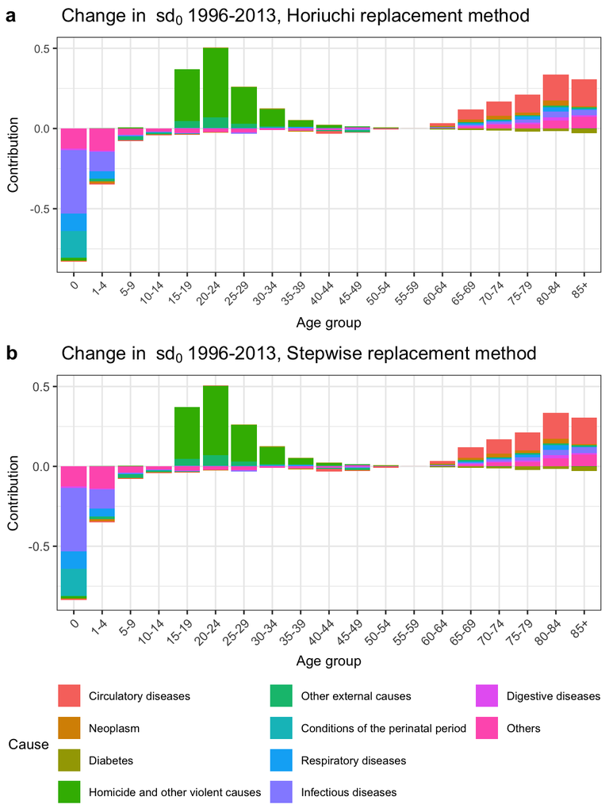

```r
p.both.sd <-  ggpubr::ggarrange(p.horiuchi.sd,
                             p.stepwise.sd,
                             ncol = 1,
                             labels = c('a', 'b'),
                             common.legend = TRUE,
                             legend = 'bottom',
                             align = 'hv',
                             widths = c(1,1),
                             heights = c(1,1))
p.both.sd
```